# Practical_machine_learning

Raghu

January 2, 2017

```r
library(caret, quietly = TRUE)
library(rpart, quietly = TRUE)
library(rpart.plot, quietly = TRUE)
library(rattle, quietly = TRUE)
library(randomForest, quietly = TRUE)
library(e1071, quietly = TRUE)
library(parallel, quietly = TRUE)
library(doParallel, quietly = TRUE)
library(gbm, quietly = TRUE)
library(knitr, quietly = TRUE)
```

## Executive Summary

Using devices such as Jawbone Up, Nike FuelBand, and Fitbit it is now possible to collect a large amount of data about personal activity relatively inexpensively. These type of devices are part of the quantified self movement - a group of enthusiasts who take measurements about themselves regularly to improve their health, to find patterns in their behavior, or because they are tech geeks. One thing that people regularly do is quantify how much of a particular activity they do, but they rarely quantify how well they do it. In this project, your goal will be to use data from accelerometers on the belt, forearm, arm, and dumbell of 6 participants. They were asked to perform barbell lifts correctly and incorrectly in 5 different ways. More information is available from the website here: http://groupware.les.inf.puc-rio.br/har (see the section on the Weight Lifting Exercise Dataset).

### Data

The training data for this project are available here: https://d396qusza40orc.cloudfront.net/predmachlearn/pml-training.csv

The test data are available here: https://d396qusza40orc.cloudfront.net/predmachlearn/pml-testing.csv

The data for this project come from this source: http://groupware.les.inf.puc-rio.br/har. If you use the document you create for this class for any purpose please cite them as they have been very generous in allowing their data to be used for this kind of assignment.

## Question

The goal of your project is to predict the manner in which they did the exercise. This is the “classe” variable in the training set. You may use any of the other variables to predict with. You should create a report describing how you built your model, how you used cross validation, what you think the expected out of sample error is, and why you made the choices you did. You will also use your prediction model to predict 20 different test cases.

## Getting Data

Download training and testing set and read into R by making all blanks as NAs.

```r
urlTraining <- "https://d396qusza40orc.cloudfront.net/predmachlearn/pml-training.csv"
download.file(url=urlTraining, destfile="./pml-training.csv")
Training <- read.csv("./pml-training.csv",
                         header = TRUE,
                         na.strings=c("NA",""))


urlTesting <- "https://d396qusza40orc.cloudfront.net/predmachlearn/pml-testing.csv"
download.file(url=urlTesting, destfile="./pml-testing.csv")
Testing <- read.csv("./pml-testing.csv",
                        header = TRUE,
                        na.strings=c("NA",""))
```

Validate all variables are same across Training and Testing datasets

```r
## read the column names from training and testing set
colnamesTraining <- colnames(Training)
colnamesTesting <- colnames(Testing)

## Verify that the column names (excluding classe and problem_id as they are
## outcomes) are identical in the training and testing set.
all.equal(colnamesTraining[1:length(colnamesTraining)-1],
          colnamesTesting[1:length(colnamesTesting)-1])
```

```
## [1] TRUE
```

check the dimension of the datasets

```r
dim(Training); dim(Testing)
```

```
## [1] 19622   160
```

```
## [1]  20 160
```

The Testing dataset refers to the 20 test cases where we will use our prediction model to predict. Hence the Training dataset will be partitioned to myTrain and myTest datasets to train the model on mytrain set and apply on myTest set to pick the best model.

```r
set.seed(8643)
inTrain <- createDataPartition(Training$classe, p=0.7, list=FALSE)
myTrain <- Training[inTrain, ]
myTest <- Training[-inTrain, ]
dim(myTrain); dim(myTest)
```

```
## [1] 13737   160
```

```
## [1] 5885  160
```

## Identify features

Remove the variables which are not significant for prediction from myTrain dataset

```r
set.seed(8643)
## Remove zero variance columns. These have the same value for most of
## the collected samples.
nzv <- nearZeroVar(myTrain, saveMetrics=TRUE)
myTrain <- myTrain[,nzv$nzv==FALSE]

## Remove the first column from myTest data set, as it is only the row number.
myTrain <- myTrain[c(-1)]

# Count the number of NAs in each column.
NAs <- function(x) {
        as.vector(apply(x, 2, function(x) length(which(is.na(x)))))
}

## Build a vector with number of NAs corresponding to each column in myTrain
## data set
NAscnts <- NAs(myTrain)

## identify columns which has more than 70% of NAs
drops <- c()
for (cnt in 1:length(NAscnts)) {
        if (NAscnts[cnt] / nrow(myTrain) > .7 ) {
                drops <- c(drops, colnames(myTrain)[cnt])
        }
}

## Drop the columns which has more than 70% of NAs. These don't hold much data
## to use it for our prediction.
myTrain <- myTrain[,!(colnames(myTrain) %in% drops)]
```

## Algorithm

Train various models on myTrain dataset. Perform the model building using multiple ways. Without any pre-processing, pre-processing (to standardize the variables) and cross validation (Splits the training set into training and test sets, builds the model on training set and evaluate on test set, repeats this process and average the estimated errors. This will give an estimate of what will happen when we get a new data set).

### Prediction with Trees

These models are easy to interpret. It iteratively splits variables into groups to evaluate homogenity within each group.

```r
set.seed(8643)
## Prediction using bootstrapping. Fig 1 in Appendix shows the rpart fancy plot.
modFitDT <- train(classe ~ ., method="rpart", data=myTrain)
## Prediction using bootstrapping and pre-processing.
modFitDT1 <- train(classe ~ ., preProcess=c("center", "scale"),
method="rpart", data=myTrain)
## Prediction using pre-processing and cross validation
modFitDT2 <- train(classe ~ ., preProcess=c("center", "scale"),
trControl=trainControl(method = "cv", number = 4), method="rpart",
data=myTrain)
```

### Prediction using Random Forest

This is an extension to classification trees. Bootstrap samples, rebuild classification trees for each of those samples.And at each split, bootstrapping happens at variables level. So only a subset of variables are considered at each split. This way a large number of diverse trees are built and averaged on them to get the prediction for a new outcome.

```r
set.seed(8643)
## Prediction using cross validation
fitControl <- trainControl(method = "cv",
                           number = 4,
                           allowParallel = TRUE)
## Enable Parallel processing
cluster <- makeCluster(detectCores() - 1) # convention to leave 1 core for OS
registerDoParallel(cluster)
## Fit the model
modFitrf <- train(classe ~ ., data=myTrain, method = "rf",
                  trControl = fitControl, prox=TRUE)
## Disable parallel processing
stopCluster(cluster)
registerDoSEQ()
```

### Prediction using Boosting

Takes in lots of weak predictors, weight them and add them up to get a stronger predictor.

```r
set.seed(8643)
## Prediction using cross validation
fitControl <- trainControl(method = "cv",
                           number = 4,
                           allowParallel = TRUE)
## Enable Parallel processing
cluster <- makeCluster(detectCores() - 1) # convention to leave 1 core for OS
registerDoParallel(cluster)
## Fit the model
modFitgm <- train(classe ~ ., data=myTrain, method = "gbm",
                  trControl = fitControl, verbose = FALSE)
## Disable parallel processing
stopCluster(cluster)
registerDoSEQ()
```

## Evaluation

Evaluate the models on myTest dataset.

### Prediction with Trees

```r
set.seed(8643)
# Prediction using bootstrapping
predictionDT <- predict(modFitDT, myTest)
cmDT <- confusionMatrix(predictionDT, myTest$classe)
cmDT$overall
```

```
##       Accuracy          Kappa  AccuracyLower  AccuracyUpper   AccuracyNull
##   4.574342e-01   3.013170e-01   4.446448e-01   4.702657e-01   2.844520e-01
## AccuracyPValue  McnemarPValue
##  4.342852e-174            NaN
```

```r
# Prediction using bootstrapping and pre-processing
predictionDT1 <- predict(modFitDT1, myTest)
cmDT1 <- confusionMatrix(predictionDT1, myTest$classe)
cmDT1$overall
```

```
##       Accuracy          Kappa  AccuracyLower  AccuracyUpper   AccuracyNull
##   4.574342e-01   3.013170e-01   4.446448e-01   4.702657e-01   2.844520e-01
## AccuracyPValue  McnemarPValue
##  4.342852e-174            NaN
```

```r
# Prediction using pre-processing and cross validation
predictionDT2 <- predict(modFitDT2, myTest)
cmDT2 <- confusionMatrix(predictionDT2, myTest$classe)
cmDT2$overall
```

```
##       Accuracy          Kappa  AccuracyLower  AccuracyUpper   AccuracyNull
##   4.574342e-01   3.013170e-01   4.446448e-01   4.702657e-01   2.844520e-01
## AccuracyPValue  McnemarPValue
##  4.342852e-174            NaN
```

### Prediction using Random Forest

Refer fig 2 in appendix for the confusion matrix

```r
set.seed(8643)
# Prediction using cross validation
predictionrf <- predict(modFitrf, myTest)
cmrf <- confusionMatrix(predictionrf, myTest$classe)
cmrf$overall
```

```
##       Accuracy          Kappa  AccuracyLower  AccuracyUpper   AccuracyNull
##      0.9988105      0.9984954      0.9975508      0.9995216      0.2844520
## AccuracyPValue  McnemarPValue
##      0.0000000            NaN
```

### Prediction using Boosting

Refer fig 3 in appendix for the confusion matrix

```r
set.seed(8643)
# Prediction using cross validation
predictiongm <- predict(modFitgm, myTest)
cmgm <- confusionMatrix(predictiongm, myTest$classe)
cmgm$overall
```

```
##       Accuracy          Kappa  AccuracyLower  AccuracyUpper   AccuracyNull
##      0.9977910      0.9972058      0.9962255      0.9988233      0.2844520
## AccuracyPValue  McnemarPValue
##      0.0000000            NaN
```

## Identifying the best prediction model

The following are the out of Sample error rates for the models:

```
## [1] "Prediction with trees (bootstrapping) (1- cmDT$overall['Accuracy']) : 0.542565845369584"
```

```
## [1] "Prediction with trees (pre-processing and bootstrapping) (1- cmDT1$overall['Accuracy']) : 0.542565845369584"
```

```
## [1] "Prediction with trees (pre-processing and cross validation) (1- cmDT2$overall['Accuracy']) : 0.542565845369584"
```

```
## [1] "Prediction using Random Forest (cross validation) (1- cmrf$overall['Accuracy']) : 0.00118946474086656"
```

```
## [1] "Prediction using Boosting (cross validation) (1- cmgm$overall['Accuracy']) : 0.00220900594732365"
```

Prediction using Random Forest has the least out of sample error rate.

## Predicting Results on the Testing Data

Prediction using Random Forest with cross validation had high accuracy rate of 99.88% on myTest dataset compared to rest of the performed models on myTest dataset. The expected out-of-sample error rate is 100 - 99.88 = 0.12%. Hence using Random Forest model object to predict the test cases.

```r
set.seed(8643)
predTestingrf <- predict(modFitrf, Testing)
predTestingrf
```

```
##  [1] B A B A A E D B A A B C B A E E A B B B
## Levels: A B C D E
```

## Appendix

### Figure 1 (Decision tree for prediction using bootstrapping)

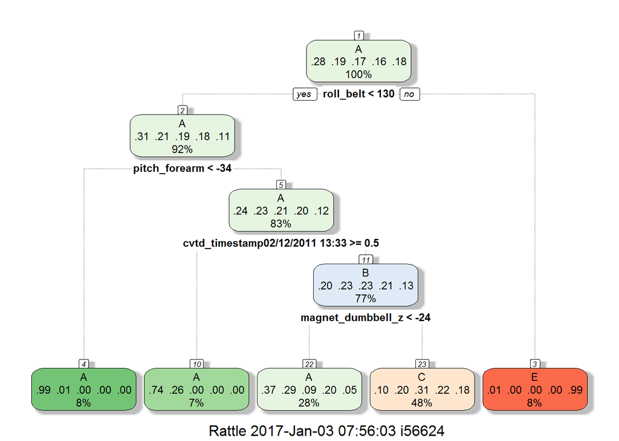

```r
fancyRpartPlot(modFitDT$finalModel)
```

### Figure 2 (Confusion matrix for random Forest)

```r
cmrf
```

```
## Confusion Matrix and Statistics
##
##           Reference
## Prediction    A    B    C    D    E
##          A 1674    2    0    0    0
##          B    0 1137    3    0    0
##          C    0    0 1023    0    0
##          D    0    0    0  963    1
##          E    0    0    0    1 1081
##
## Overall Statistics
##
##                Accuracy : 0.9988
##                  95% CI : (0.9976, 0.9995)
##     No Information Rate : 0.2845
##     P-Value [Acc > NIR] : < 2.2e-16
##
##                   Kappa : 0.9985
##  Mcnemar's Test P-Value : NA
##
## Statistics by Class:
##
##                      Class: A Class: B Class: C Class: D Class: E
## Sensitivity            1.0000   0.9982   0.9971   0.9990   0.9991
## Specificity            0.9995   0.9994   1.0000   0.9998   0.9998
## Pos Pred Value         0.9988   0.9974   1.0000   0.9990   0.9991
## Neg Pred Value         1.0000   0.9996   0.9994   0.9998   0.9998
## Prevalence             0.2845   0.1935   0.1743   0.1638   0.1839
## Detection Rate         0.2845   0.1932   0.1738   0.1636   0.1837
## Detection Prevalence   0.2848   0.1937   0.1738   0.1638   0.1839
## Balanced Accuracy      0.9998   0.9988   0.9985   0.9994   0.9994
```

### Figure 3 (Confusion matrix for Boosting)

```r
cmgm
```

```
## Confusion Matrix and Statistics
##
##           Reference
## Prediction    A    B    C    D    E
##          A 1674    3    0    0    0
##          B    0 1135    1    0    0
##          C    0    1 1023    0    0
##          D    0    0    2  963    5
##          E    0    0    0    1 1077
##
## Overall Statistics
##
##                Accuracy : 0.9978
##                  95% CI : (0.9962, 0.9988)
##     No Information Rate : 0.2845
##     P-Value [Acc > NIR] : < 2.2e-16
##
##                   Kappa : 0.9972
##  Mcnemar's Test P-Value : NA
##
## Statistics by Class:
##
##                      Class: A Class: B Class: C Class: D Class: E
## Sensitivity            1.0000   0.9965   0.9971   0.9990   0.9954
## Specificity            0.9993   0.9998   0.9998   0.9986   0.9998
## Pos Pred Value         0.9982   0.9991   0.9990   0.9928   0.9991
## Neg Pred Value         1.0000   0.9992   0.9994   0.9998   0.9990
## Prevalence             0.2845   0.1935   0.1743   0.1638   0.1839
## Detection Rate         0.2845   0.1929   0.1738   0.1636   0.1830
## Detection Prevalence   0.2850   0.1930   0.1740   0.1648   0.1832
## Balanced Accuracy      0.9996   0.9981   0.9984   0.9988   0.9976
```